# CNN X-ray Pneumonia detection without transfer learning: 95% test accuracy

**Abstract**

The purpose of this script is to build a CNN model from scratch, understand various stages, play around with mode architecture and regularization to achieve in the end a relatively good test accuracy. The final result shows close to 95% accuracy on test dataset.

Key highlights:

- Create a model from scratch without transfer learning.
- Gain insights on how the depth and width of the model affects the loss curve
- Write custom callbacks for saving best model or early stopper

```python
import os
import zipfile
import random
import shutil
from shutil import copyfile
from os import getcwd
import pathlib
import datetime

import cv2
from PIL import Image


import tensorflow_datasets as tfds
import tensorflow as tf
from tensorflow import keras
from tensorflow.keras import layers
from tensorflow.keras.preprocessing import image_dataset_from_directory
from tensorflow.keras.preprocessing.image import ImageDataGenerator
from tensorflow.keras.optimizers import RMSprop, Adam, SGD
from tensorflow.keras.callbacks import TensorBoard
from tensorflow.keras.models import model_from_json
from sklearn.model_selection import train_test_split


import matplotlib.pylab as plt
import numpy as np

#Write twice, because sometimes it does not work the first time, especially if you are switching back to notebook
%matplotlib notebook
%matplotlib notebook
```

## Set path of the dataset

```python
current_working_dir = os.getcwd()

path_to_images = pathlib.Path(os.path.join(current_working_dir, 'chest_xray_images'))
path_to_training = pathlib.Path(os.path.join(path_to_images, 'train'))
path_to_testing = pathlib.Path(os.path.join(path_to_images, 'test'))

#============ Total training images ===============
total_images = 0
for root, dirs, files in os.walk(path_to_training):
    total_images += len(files)
print("Total training images: ", total_images)

#=============== Total testing images ===============
total_images = 0
for root, dirs, files in os.walk(path_to_testing):
    total_images += len(files)
print("Total testing images: ", total_images)

#=============== Total images ===============
total_images = 0
for root, dirs, files in os.walk(path_to_images):
    total_images += len(files)
print("Total  images: ", total_images)
```

```
Total training images:  5216
Total testing images:  624
Total  images:  5856
```

## Create data feeder

- Resize images
- set batch size
- seed to shuffle and randomly dividing the training and validation dataset
- parameters for image augmentation

```python
new_img_size = (225, 225)
batch_size = 32

train_datagen = ImageDataGenerator(
    rescale=1./255,
    shear_range=0.2,
    zoom_range=0.35,
    #vertical_flip=True,
)

test_datagen = ImageDataGenerator(rescale=1./255)


seed = 107
training_ds = train_datagen.flow_from_directory(path_to_training,
                                                seed=seed,
                                                shuffle=True,
                                                target_size=new_img_size,
                                                batch_size=batch_size,
                                                class_mode='binary')

test_ds = test_datagen.flow_from_directory(path_to_testing,
                                           shuffle=True,
                                           seed=seed,
                                           target_size=new_img_size,
                                           batch_size=batch_size,
                                           class_mode='binary')
```

```
Found 5216 images belonging to 2 classes.
Found 624 images belonging to 2 classes.
```

```python
class_names = training_ds.class_indices
print(class_names)

#invert the dictionary
class_names = {v: k for k, v in class_names.items()}
print(class_names)
```

```
{'NORMAL': 0, 'PNEUMONIA': 1}
{0: 'NORMAL', 1: 'PNEUMONIA'}
```

## Inspect some images

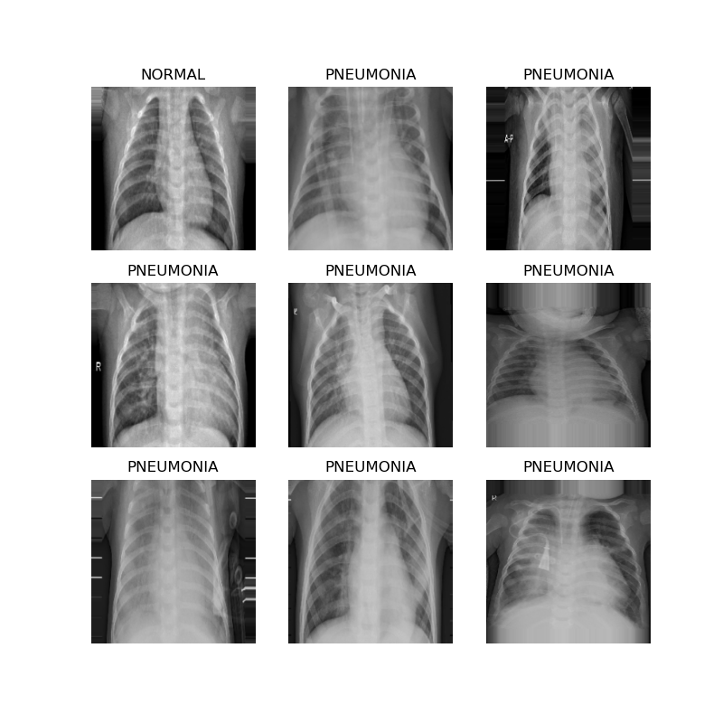

```python
plt.figure(figsize=(8, 8))
image_batch, label_batch = training_ds.next()
for i in range(9):
    ax = plt.subplot(3, 3, i + 1)
    plt.imshow(image_batch[i])
    plt.title(class_names[label_batch[i]])
    plt.axis("off")
```

# Create model

Use at least 3 layers. The number of filters are increased progressively starting with 16. We use dropout as regularization to avoid over fitting. We do not want high dropout in the initial layers, usually it is progressively increased over the deeper layers. And finally, since we are using ReLu activation function, using kernel_initializer='he_uniform' is highly recommended.

```python
# lr_reduce = tf.keras.callbacks.ReduceLROnPlateau(monitor='val_acc', factor=0.1, min_delta=0.0001, patience=3, verbose=1)
lr_reduce = tf.keras.callbacks.ReduceLROnPlateau(monitor='val_loss', factor=0.1, patience=4, verbose=2, mode='max')
```

```python
model = tf.keras.models.Sequential([
    #ayers.experimental.preprocessing.Rescaling(1./255,input_shape=(new_img_size[0],new_img_size[1],3)),
    #tf.keras.layers.experimental.preprocessing.RandomFlip('horizontal'),
    #tf.keras.layers.experimental.preprocessing.RandomRotation(0.3),

    tf.keras.layers.Conv2D(16, (3,3), input_shape=(new_img_size[0],new_img_size[1],3), activation='relu', kernel_initializer='he_uniform', padding='same'),
    tf.keras.layers.Conv2D(16, (3,3), activation='relu', kernel_initializer='he_uniform', padding='same'),
    tf.keras.layers.BatchNormalization(),
    tf.keras.layers.MaxPool2D(2,2),
    #tf.keras.layers.Dropout(0.2),

    tf.keras.layers.SeparableConv2D(32, (3,3), activation='relu', kernel_initializer='he_uniform', padding='same'),
    tf.keras.layers.SeparableConv2D(32, (3,3), activation='relu', kernel_initializer='he_uniform', padding='same'),
    tf.keras.layers.BatchNormalization(),
    tf.keras.layers.MaxPool2D(2,2),
    #tf.keras.layers.Dropout(0.2),

    tf.keras.layers.SeparableConv2D(64, (3,3), activation='relu', kernel_initializer='he_uniform', padding='same'),
    tf.keras.layers.SeparableConv2D(64, (3,3), activation='relu', kernel_initializer='he_uniform', padding='same'),
    tf.keras.layers.BatchNormalization(),
    tf.keras.layers.MaxPool2D(2,2),
    #tf.keras.layers.Dropout(0.2),

    tf.keras.layers.SeparableConv2D(128, (3,3), activation='relu', kernel_initializer='he_uniform', padding='same'),
    tf.keras.layers.SeparableConv2D(128, (3,3), activation='relu', kernel_initializer='he_uniform', padding='same'),
    tf.keras.layers.BatchNormalization(),
    tf.keras.layers.MaxPool2D(2,2),
    tf.keras.layers.Dropout(0.2),

    tf.keras.layers.SeparableConv2D(256, (3,3), activation='relu', kernel_initializer='he_uniform', padding='same'),
    tf.keras.layers.SeparableConv2D(256, (3,3), activation='relu', kernel_initializer='he_uniform', padding='same'),
    tf.keras.layers.BatchNormalization(),
    tf.keras.layers.MaxPool2D(2,2),
    tf.keras.layers.Dropout(0.2),

    tf.keras.layers.Flatten(),
    tf.keras.layers.Dense(512, activation='relu', kernel_initializer='he_uniform'),
    #tf.keras.layers.BatchNormalization(),
    tf.keras.layers.Dropout(0.5),

    tf.keras.layers.Dense(128, activation='relu', kernel_initializer='he_uniform'),
    #tf.keras.layers.BatchNormalization(),
    tf.keras.layers.Dropout(0.3),

    tf.keras.layers.Dense(64, activation='relu', kernel_initializer='he_uniform'),
    #tf.keras.layers.BatchNormalization(),
    tf.keras.layers.Dropout(0.3),

    tf.keras.layers.Dense(1, activation='sigmoid')
])
```

```python
learning_rate = 0.0005

model.compile(optimizer='adam', loss='binary_crossentropy', metrics=['acc']) #SGD(lr=0.007, momentum=0.9), #RMSprop(lr=0.0001), #Adam(lr=0.001)
#model.compile(optimizer='adam', loss='binary_crossentropy', metrics=['acc'])

#print(model.summary())
```

## Create callbacks

```python
#==================================================
# This function keeps the initial learning rate for the first ten epochs
# and decreases it exponentially after that.
# def scheduler(epoch, lr):
#     if epoch < 10:
#         return lr
#     else:
#         return lr * tf.math.exp(-0.1)

# lr_callback = tf.keras.callbacks.LearningRateScheduler(scheduler)

#==================================================
#==================================================

class MyThresholdCallback(tf.keras.callbacks.Callback):
    def __init__(self, threshold):
        super(MyThresholdCallback, self).__init__()
        self.threshold = threshold

    def on_epoch_end(self, epoch, logs=None):
        val_acc = logs["val_acc"]
        if val_acc >= self.threshold:
            self.model.stop_training = True

early_stopping_callback = MyThresholdCallback(threshold=0.951)
```

```python
logdir = os.path.join(
    "logs", datetime.datetime.now().strftime("%Y%m%d-%H%M%S"))

modelfname = datetime.datetime.now().strftime("%Y%m%d-%H%M%S")+'bs_'+ str(batch_size) + 'lr' + str(learning_rate) +'.h5'


model_folder = pathlib.Path(os.path.join(current_working_dir,'model'))
mcp_save = tf.keras.callbacks.ModelCheckpoint(os.path.join(model_folder, modelfname), save_best_only=True, monitor='val_loss', mode='min')

tensorboard_callback = tf.keras.callbacks.TensorBoard(logdir, histogram_freq=1)

print(logdir)
# # ======= Go to the logs folder within the current project. ===========
# # ======= Open a terminal, activate correct env, run following command to launch tensorboard
# # tensorboard --port=6007 --logdir ~/logs
# # =====================================================================

epochs = 200
history = model.fit(
    training_ds,
    validation_data=test_ds,
    epochs=epochs,
    verbose=1,
    callbacks=[tensorboard_callback, mcp_save, early_stopping_callback] #lr_reduce
)

#model.save(os.path.join(model_folder, modelfname))
```

```
logs/20201105-065549
```

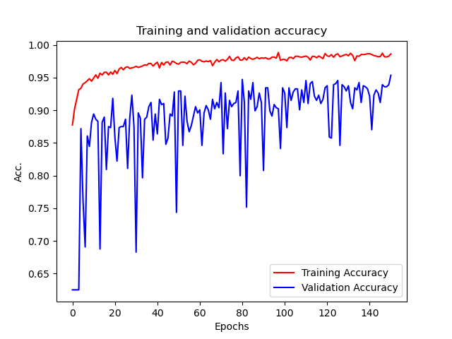

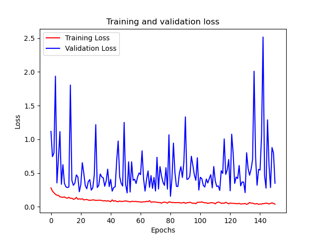

```python
# PLOT LOSS AND ACCURACY

#import matplotlib.image  as mpimg
#import matplotlib.pyplot as plt
#-----------------------------------------------------------
# Retrieve a list of list results on training and test data
# sets for each training epoch
#-----------------------------------------------------------
acc=history.history['acc']
val_acc=history.history['val_acc']
loss=history.history['loss']
val_loss=history.history['val_loss']

epochs=np.arange(len(acc)) # Get number of epochs

#------------------------------------------------
# Plot training and validation accuracy per epoch
#------------------------------------------------
plt.figure()
plt.plot(epochs, acc, 'r', label="Training Accuracy")
plt.plot(epochs, val_acc, 'b', label="Validation Accuracy")
plt.xlabel("Epochs")
plt.ylabel("Acc.")
plt.title('Training and validation accuracy')
plt.legend()
#------------------------------------------------
# Plot training and validation loss per epoch
#------------------------------------------------
plt.figure()
plt.plot(epochs, loss, 'r', label="Training Loss")
plt.plot(epochs, val_loss, 'b', label="Validation Loss")
plt.xlabel("Epochs")
plt.ylabel("Loss")
plt.legend()

plt.title('Training and validation loss')

# Desired output. Charts with training and validation metrics. No crash :)
```

## Save and Load best model

```python
# serialize model to JSON
model_json = model.to_json()
with open(pathlib.Path(os.path.join(current_working_dir,'model','best_model','model_structure.json')), "w") as json_file:
    json_file.write(model_json)
```

```python
# load json and create model
json_file = open(pathlib.Path(os.path.join(current_working_dir, 'model', 'best_model', 'model_structure.json')), 'r')
loaded_model_json = json_file.read()
json_file.close()

loaded_model = model_from_json(loaded_model_json)
# load weights into new model
loaded_model.load_weights(pathlib.Path(os.path.join(
    current_working_dir, 'model', 'best_model', modelfname)
)
)

print("Loaded model from disk")

# use loaded model on test data
# loaded_model.compile(loss='binary_crossentropy',
#                      optimizer='rmsprop', metrics=['accuracy'])
```

```
Loaded model from disk
```

# Predictions

## Test on validation set images

```
Prediction:  PNEUMONIA  | Truth:  PNEUMONIA
Score:  1.0
```

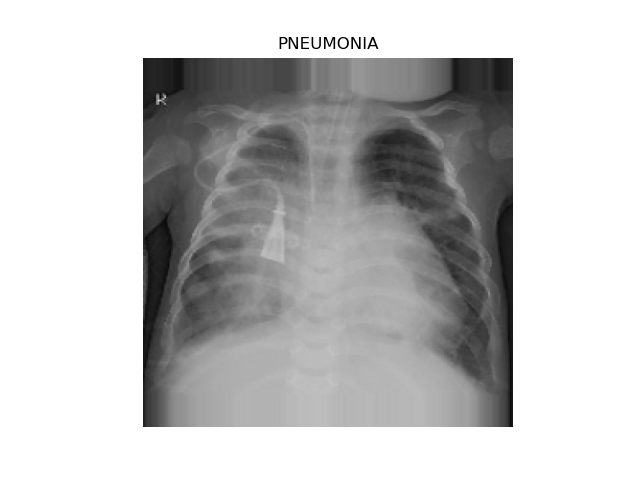

```
(-0.5, 224.5, 224.5, -0.5)
```

```python
image_batch, label_batch = test_ds.next()
i = random.randint(0,batch_size-1)

img_array = keras.preprocessing.image.img_to_array(image_batch[i])
img_array = tf.expand_dims(img_array, 0)  # Create batch axis

true_class = int(label_batch[i])
predicted_class = model.predict_classes(img_array)[0]
predictions = model.predict(img_array)
score = predictions.flatten()[0]

print("Prediction: ",class_names[predicted_class[0]], " | Truth: ", class_names[true_class])
print("Score: ", np.round(score,2))

plt.figure()
plt.imshow(image_batch[i])
plt.title(class_names[true_class])
plt.axis("off")
```

# Conclusions

We have developed Convolutional Neural Network based model without using any pre-trained models or transfer learning methods. This model achieves accuracy of ~95% on test dataset. Notice that the validation loss curve fluctuates a lot around a more or less constant average value. Whereas the training loss improves slowly. This is a clear indication of over fitting. The orver fitting is suppressed quite a bit by using dropouts. There is still some opportunity to improve the model.